# IE360HW1

Halis Oguz

2022-04-11

```
require(ggplot2)
require(data.table)
require(skimr)
require(GGally)
require(ggcorrplot)
require(forecast)
require(openxlsx)
require(lubridate)
require(forecast)
setwd("/Users/halis/Desktop")
fiyat=read.xlsx("EVDS_fiyat_endeksleri.xlsx")
evfiyat=read.csv("evfiyatları.csv")
str(fiyat)
tail(fiyat,25)
evfiyat = data.table(evfiyat)
evfiyat
x <- c(evfiyat$Kategori..Tüm.kategoriler)
y <- rep(0,73)
for(i in 1:73){
  y[i] <- x[i+1]
}
y
y = as.numeric(y)

fiyat = data.table(fiyat)
fiyat = fiyat[,trevfiyatlar := y]
```

## Introduction

In this homework, some interesting macro economic variables’ relationships are evaluated. Interesting macro economic variables are chosen from the https://evds2.tcmb.gov.tr/. The numerical information in the data set is gathered real time and most likely a genuine collection. Its frequency is monthly due to the overall consistence and interpretability of one data group with the others.

The meanings of the variables summarized:

COL : General Cost of Living Index

COLT : Cost of Living Index for Transportation and Communication

TPKMB06 : Private Sector Level

TPKMB012 : Automobile Loans Level

TP.OSKVBG06 : Non-Bank Private Sector Credit(Loan) Level

TP.OSKVBG07 : Non-Bank Private Sector Short Term Loans from Abroad Sources

TP.YD24 : Wholesale Trade Amount

TP.YD25 : Transportation Trade Amount

```r
#fiyat2=data.table(fiyat)
#fiyat2 <- fiyat2[,date := ym(Tarih)]
#str(fiyat2)

#fiyatnumerics = copy(fiyat)
#fiyatnumerics = fiyatnumerics[,-1]
```

## Correlation Check and Data Visualization

Among our distinct data groups, the correlation information is analyzed in order to assess the related macro values. Then their plots are drawn to visualize and demonstrate the relation present.

[output not shown]

[figure not shown]

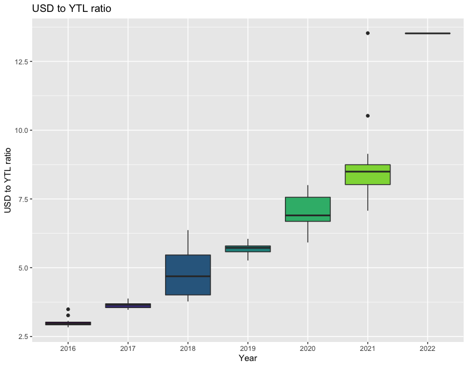

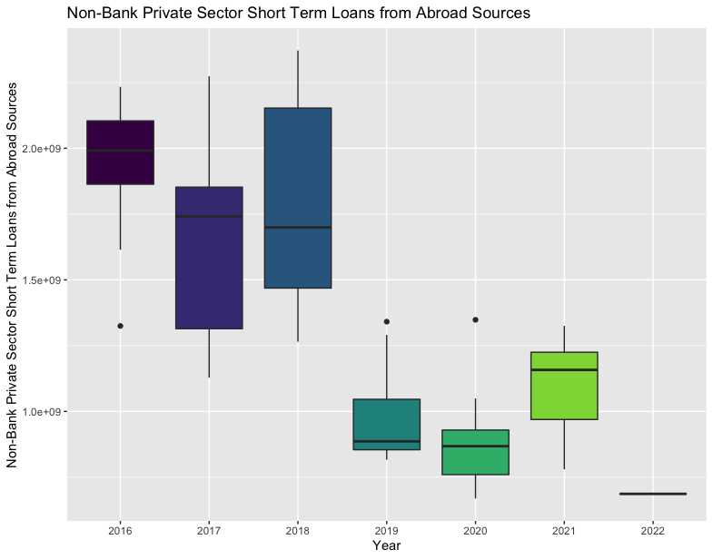

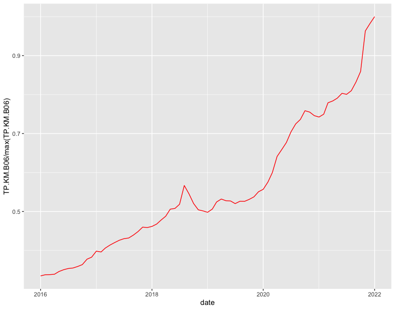

[figure not shown]

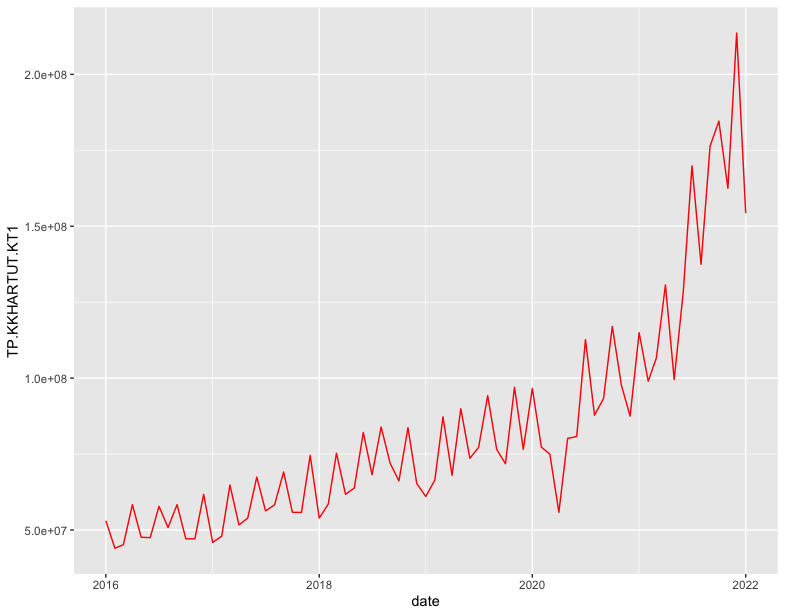

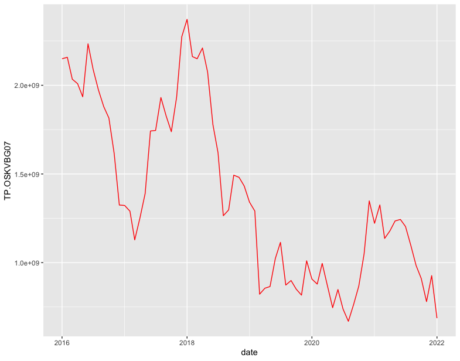

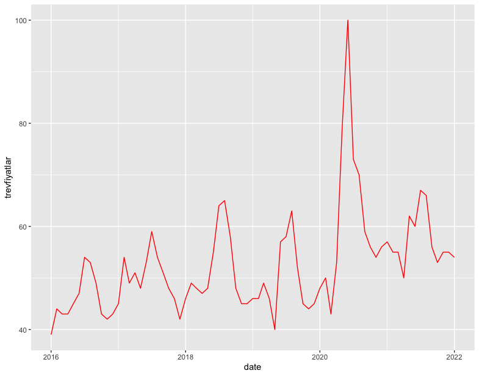

As the general cost of living increases, one could see that the debts taken from abroad sources are decreasing. These two variables are negatively correlated.

## Conclusion

One could conclude that as the private sector’s volume increases, the USD is also increasing with respect to the value of the TL. Also, it is seen that the credit cards are used much more widely as the general cost of living index increases. As the general cost of living increases, the national currency loses value which makes getting debt from external sources more expensive and undesirable. Thus, the short term loans taken from abroad shrinks with the increase of the cost of living. As the private sector in Turkey enlarged, the search volume for “ev fiyatları” in Turkey increased which shows there is an increasing concern for a basic need. The survival skills are more active with the developments in the private sector, or one could say capitalism.